# Analysis on Employees Attrition : IBM’s HR Records

> **Introduction**

This report provides analysis backed with various visualizations to reveal potential factors that contribute to attrition level in the corporate realm. The dataset used in this report was synthetically created by IBM’s data scientists to simulate real life cases of HR analytics and employees’ behaviors. The dataset was published on Kaggle website [Link](https://www.kaggle.com/pavansubhasht/ibm-hr-analytics-attrition-dataset).

The content of the dataset contains several characteristics of employees and their attitudes towards their work such job involvement, education level, years since last promotion, monthly salary and the distance they commute to their office place from their homes.

```
## Observations: 1,470
## Variables: 31
## $ Attrition                <fctr> Yes, No, Yes, No, No, No, No, No, No...
## $ BusinessTravel           <fctr> Travel_Rarely, Travel_Frequently, Tr...
## $ DailyRate                <int> 1102, 279, 1373, 1392, 591, 1005, 132...
## $ Department               <fctr> Sales, Research & Development, Resea...
## $ DistanceFromHome         <int> 1, 8, 2, 3, 2, 2, 3, 24, 23, 27, 16, ...
## $ Education                <ord> College, Below College, College, Mast...
## $ EducationField           <fctr> Life Sciences, Life Sciences, Other,...
## $ EnvironmentSatisfaction  <ord> Medium, High, Very High, Very High, L...
## $ Gender                   <fctr> Female, Male, Male, Female, Male, Ma...
## $ HourlyRate               <int> 94, 61, 92, 56, 40, 79, 81, 67, 44, 9...
## $ JobInvolvement           <ord> High, Medium, Medium, High, High, Hig...
## $ JobLevel                 <int> 2, 2, 1, 1, 1, 1, 1, 1, 3, 2, 1, 2, 1...
## $ JobRole                  <fctr> Sales Executive, Research Scientist,...
```

[output cut: 18 more lines]

Displaying a sample of selected observations 500 to 505:

```
##     Attrition    BusinessTravel DailyRate             Department
## 500        No     Travel_Rarely      1216                  Sales
## 501        No     Travel_Rarely       646 Research & Development
## 502        No Travel_Frequently       160 Research & Development
## 503        No     Travel_Rarely       238                  Sales
## 504        No     Travel_Rarely      1397 Research & Development
## 505       Yes Travel_Frequently       306                  Sales
##     DistanceFromHome     Education EducationField EnvironmentSatisfaction
## 500                8        Master      Marketing                    High
## 501                9        Master  Life Sciences                     Low
## 502                3      Bachelor        Medical                    High
## 503                1 Below College        Medical               Very High
## 504                1        Doctor  Life Sciences                  Medium
## 505               26        Master  Life Sciences                     Low
##     Gender HourlyRate JobInvolvement JobLevel            JobRole
```

[output cut: 41 more lines]

With using the library **psych**, we can get more in-depth statistics such as *standard deviation*,*mad* (mean absolute deviation) and *skew* (measures if the data distribution is symmetrical):

```
##                vars    n  mean    sd median trimmed   mad min max range
## Age               1 1470 36.92  9.14     36   36.47  8.90  18  60    42
## HourlyRate        2 1470 65.89 20.33     66   66.02 26.69  30 100    70
## YearsAtCompany    3 1470  7.01  6.13      5    5.99  4.45   0  40    40
##                 skew kurtosis   se
## Age             0.41    -0.41 0.24
## HourlyRate     -0.03    -1.20 0.53
## YearsAtCompany  1.76     3.91 0.16
```

# Univariate Plots Section

As explained earlier, the dateset was essentially built to analyze the case of employees attrition at IBM, therefore; the dataset contains a factor variable named *Attrition* with two levels (Yes, No) that says if the employee with such features attrited or not.

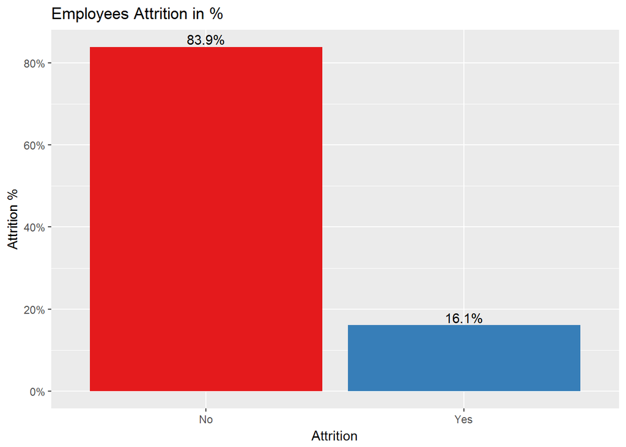

```
##
##   No  Yes
## 1233  237
```

only 16% of the employees have left the company, that is 237 out of 1470 total employee count. This could raise an instrinc issue of the dataset since it is clearly biased towards employees who opt to stay at the company. Either way, let us build our first histogram to represent the *Age* variable of all employees.

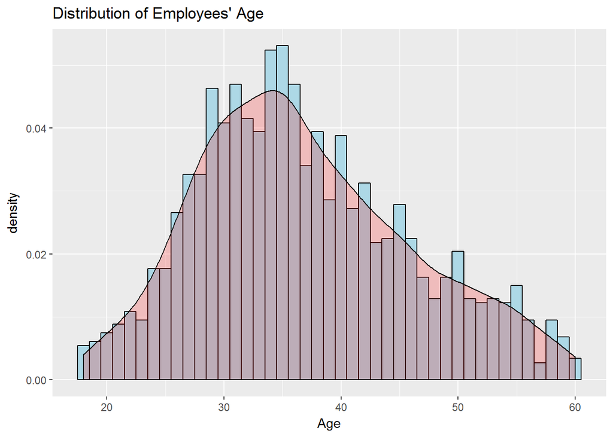

The distribution of the age variable looks almost a bell-curved (Normal Distribution) where the median/mean are closely equal around the center. Let us do the same histogram but with additional measures of central tendency.

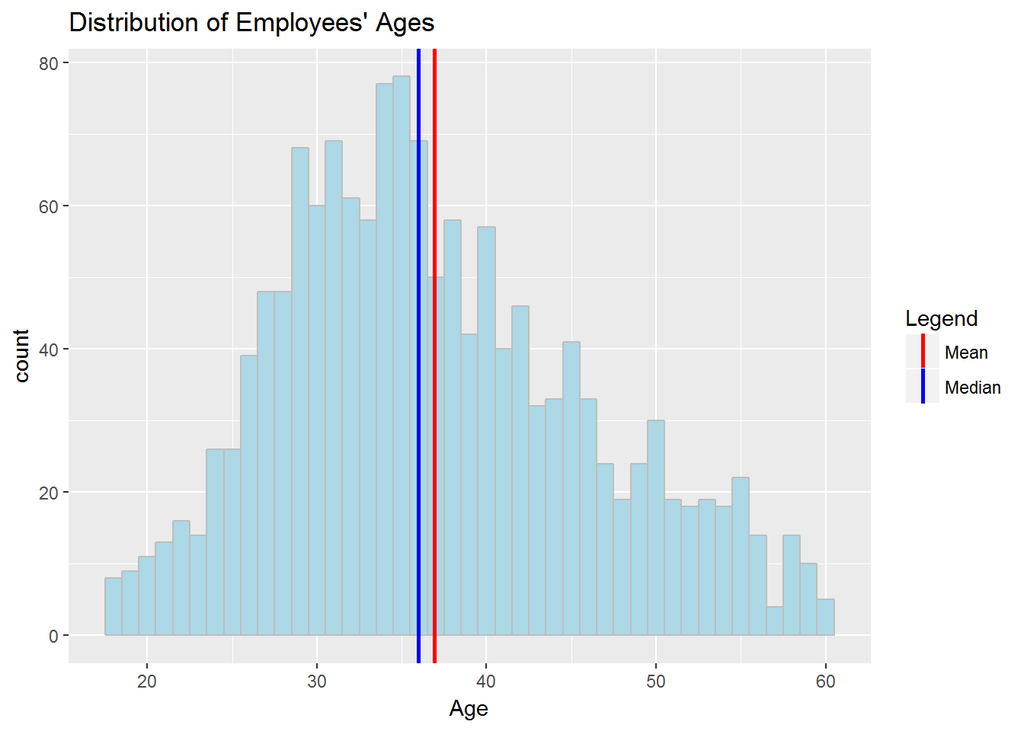

As we can see the mean & median are more than 20 years away from retirement age, the Company seems to be highly depended on segment of employees younger than 40 years old to carry out its operations. But does the company hire both gender almost equally? Let us find out.

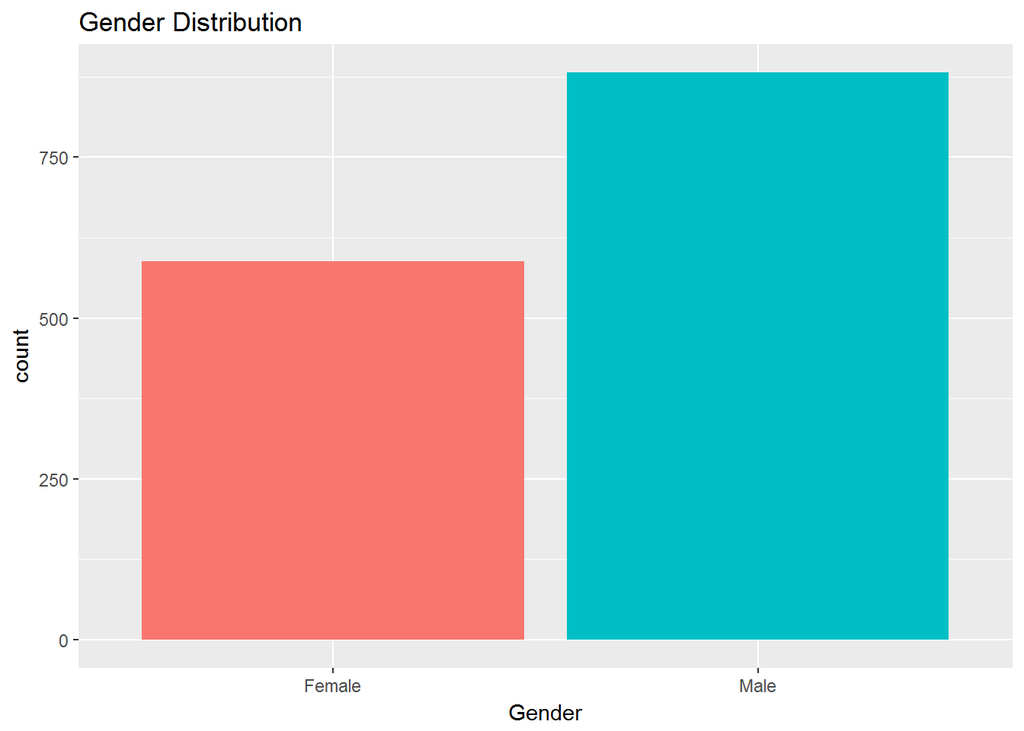

Clearly, males are dominating by almost a 1/3.

Since the dataset has more than 30 variables, we will focus on variables which might have great influence for determining job satisfaction and hence lower the unpleasant attrition rate; which is a very problematic case for many companies.

We will start exploring more variables that may highly be involved with determining employees’ attrition.

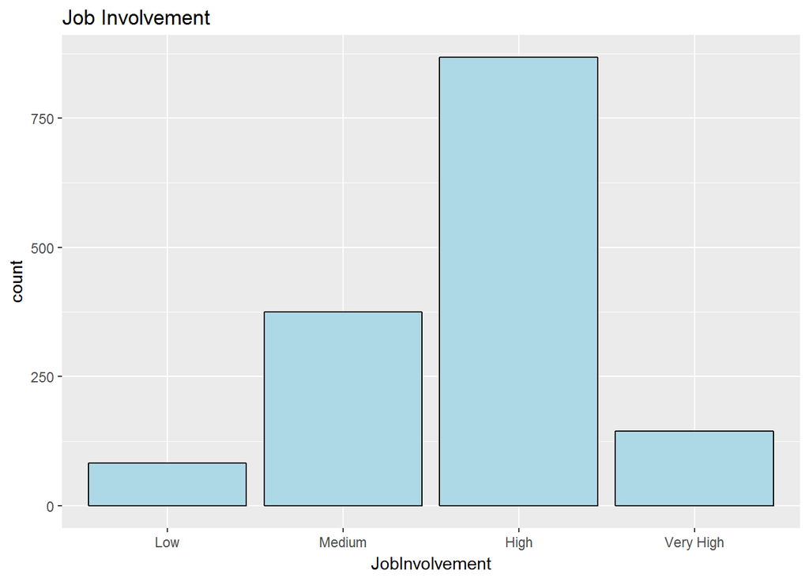

Most of the employees considered their involvement with their jobs as High which could correlate with their overall job satisfaction, whereas a small group of fewer than 100 employees exhibited the opposite.

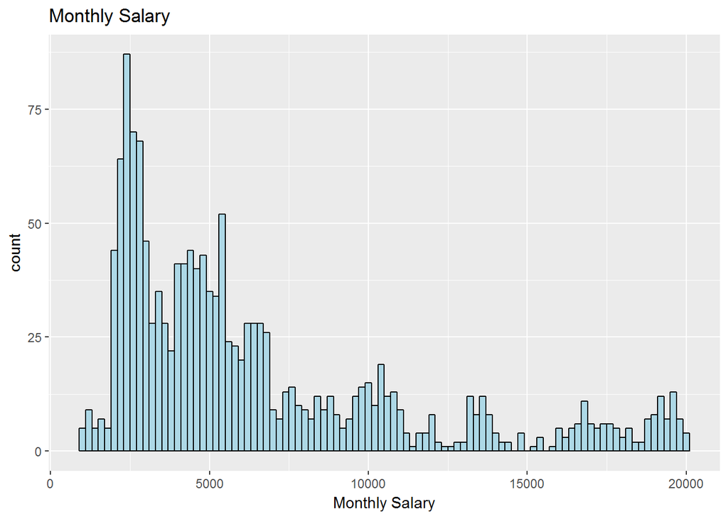

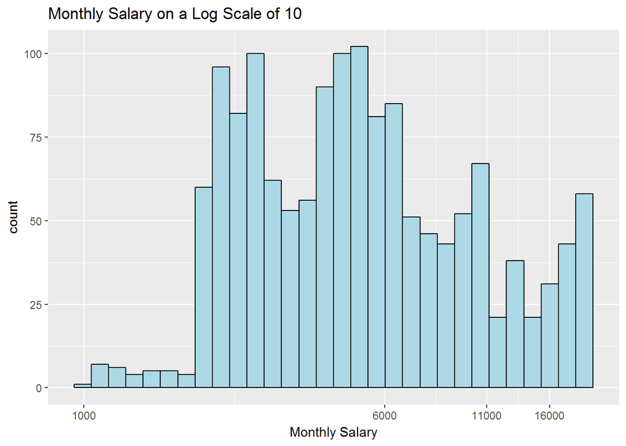

The monthly salary variable is highly right-skewed, and that makes sense in the realm of corporations in which the operational level accounts for the biggest segment of workforce and generally receives the least amount of monthly payment. After plotting with a log scale of 10, we notice a jump in the count of employees upon the monthly salary of 2000. This might be caused from the salary difference between interns and full-time employees.

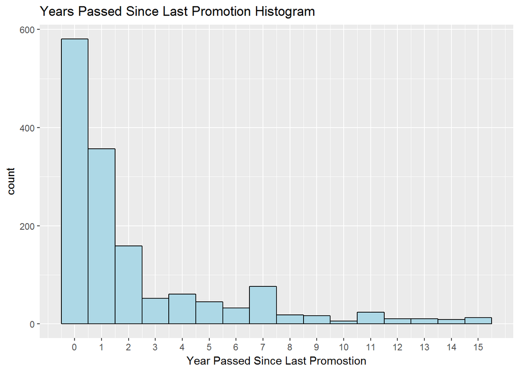

```
##    Min. 1st Qu.  Median    Mean 3rd Qu.    Max.
##   0.000   0.000   1.000   2.188   3.000  15.000
```

```
##
##   0   1   2   3   4   5   6   7   8   9  10  11  12  13  14  15
## 581 357 159  52  61  45  32  76  18  17   6  24  10  10   9  13
```

This histogram shows how many years have been passed since the employee’s last promotion. The mean of acquiring a new promotion is two years and a month, with suspicious outliers of 15 years without ever being promoted.

# Univariate Analysis

### What is the structure of your dataset?

The IBM’s Employees dataset contains 1470 observations and 31 variables (after cleaning) as follows:

```
##  [1] "Attrition"                "BusinessTravel"
##  [3] "DailyRate"                "Department"
##  [5] "DistanceFromHome"         "Education"
##  [7] "EducationField"           "EnvironmentSatisfaction"
##  [9] "Gender"                   "HourlyRate"
## [11] "JobInvolvement"           "JobLevel"
## [13] "JobRole"                  "JobSatisfaction"
## [15] "MaritalStatus"            "MonthlyIncome"
## [17] "MonthlyRate"              "NumCompaniesWorked"
## [19] "OverTime"                 "PercentSalaryHike"
## [21] "PerformanceRating"        "RelationshipSatisfaction"
## [23] "StockOptionLevel"         "TotalWorkingYears"
## [25] "TrainingTimesLastYear"    "WorkLifeBalance"
## [27] "YearsAtCompany"           "YearsInCurrentRole"
## [29] "YearsSinceLastPromotion"  "YearsWithCurrManager"
## [31] "Age"
```

The dataset includes factor variables like:

Attrition (Yes,No). Gender (Male, Female). Marital Status (Married,Single,Divorced).

Also, there are ordered variables such as:

Job Involvement (Low, Medium, High, Very High). Work Life Balance (Bad, Good, Better, Best). Environment Satisfaction (Low, Medium, High, Very High).

### What is/are the main feature(s) of interest in your dataset?

Job Involvement, Work Life Balance, Years Since Last Promotions are the main features to determine if the subject employee is satisfied with his/her job or not, hence the Attrition variable decides the outcomes.

### What other features in the dataset do you think will help support your investigation into your feature(s) of interest?

I believe the dataset has other supporting features such as Environment Satisfaction where the workplace environment plays a critical role into an employee’s overall job satisfaction. Another supporting feature would be Relationship Satisfaction that takes into account how the employees feel towards their managers. It is commonly said that “People Leave Managers, Not Companies” and it would be worthy to investigate that later on.

### Did you create any new variables from existing variables in the dataset?

No.

### Of the features you investigated, were there any unusual distributions? Did you perform any operations on the data to tidy, adjust, or change the form of the data? If so, why did you do this?

The variable Performance Rating exhibits unexpected rating pattern in such way that all employees have been rated as either Outstanding or Excellent, although, as stated in the data description, the variable Performance Rating has 4 ordered levels (Outstanding, Excellent, Good, Low). Could the company has a unique unprecedented rating system different from the corporate norms?

I adjusted factor variables (Education, WorkLifeBalance,JobInvolvement, JobSatisfaction, EnvironmentSatisfaction, RelationshipSatisfaction) to be ordered variables since it is reasonable to arrange such levels due to their natural ordinality.

I removed a variable named *Over18* since originally all the listed employees are above 18, as well those duplicated variables that have no variability whatsoever. (EmployeeCount, StandardHours,EmployeeNumber)

# Bivariate Plots Section

We will begin the bivariate section by making a correlation table (Pearson Coefficent Correlation) that would help in giving an overview of potenial correlations between the dataset’s variables.

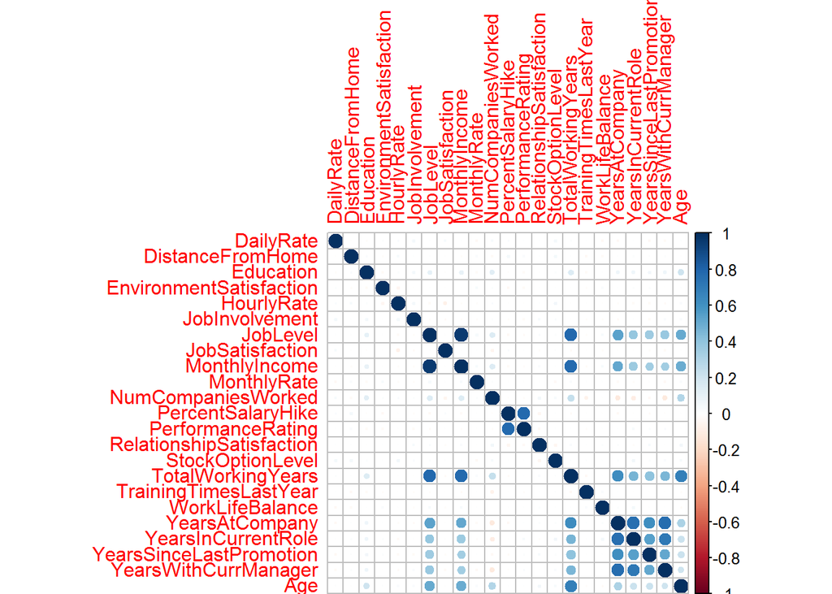

There are logical strong correlations shown in the table such as *Age* and *TotalWorkingYears*, However such ordinary relationships would not reveal interesting patterns and valuable insights. Consequently, we will bring our attention to correlations that are worthy to investigate further, for example, the table above shows a strong positive correlation between *YearsSinceLastPromostion* and *YearsAtCompany*! Does that mean the more years an employee spends serving the company, the less likely he/she gets promoted? We will discover such pattern later on.

Since our focus on why employees may opt to leave the company which raises the problematic attrition level, it would be interesting to find out the attrition percentage for both gender to have an initial overview.

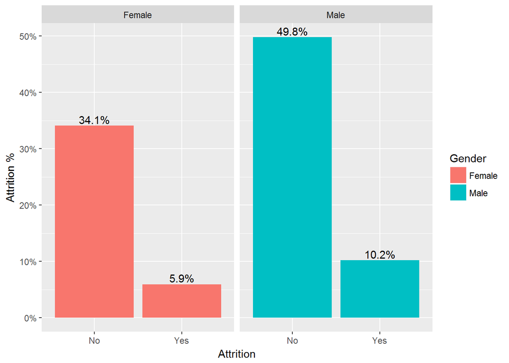

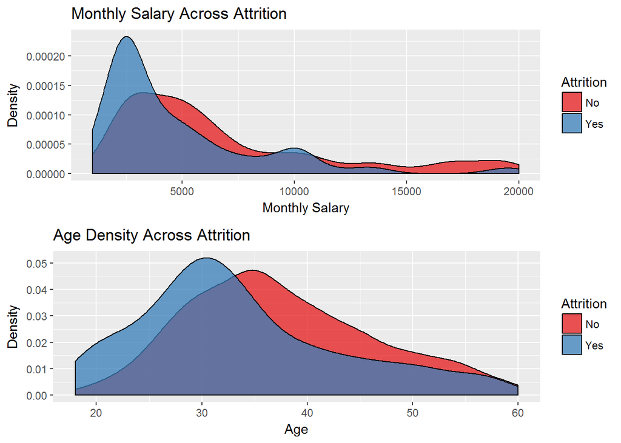

A notable variation is spotted when spreading out the monthly salary for employees who attrited against those who stayed at 5000 and below, and a minor spark at 10000. If we conduct a similar density chart for employees’ age, we can identify a close pattern where younger employees had higher chance of attrition up to around 35. Such behavior could be referred as young employees have agility and more flexibility to land on new jobs as the opposite of older employees who relatively hold their current jobs until retirement.

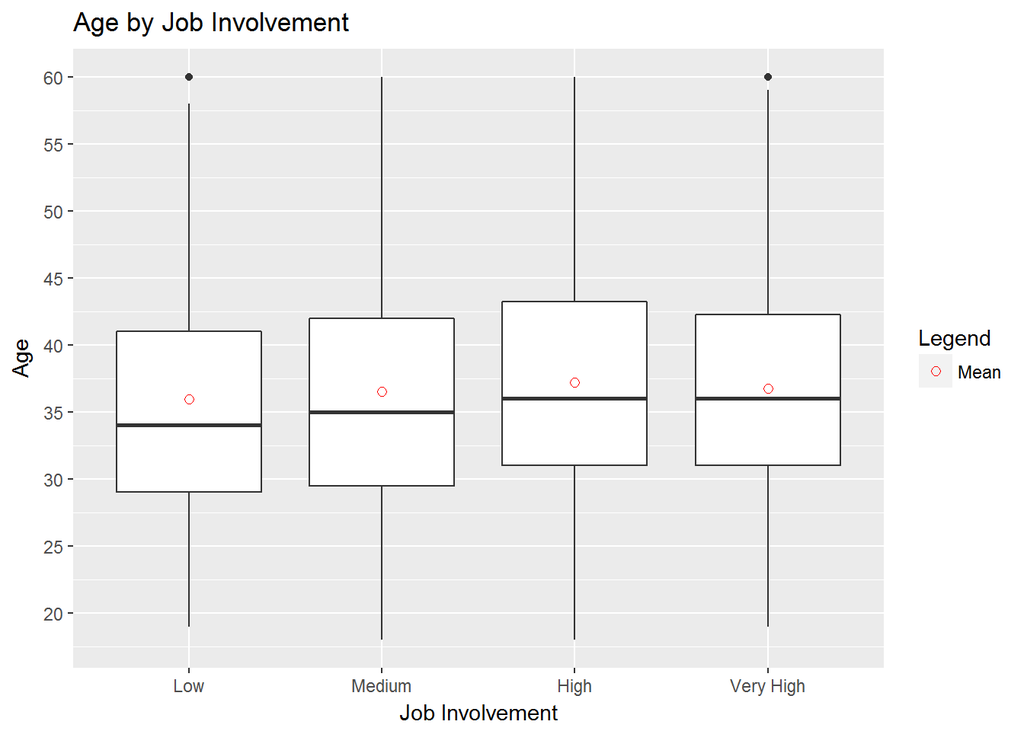

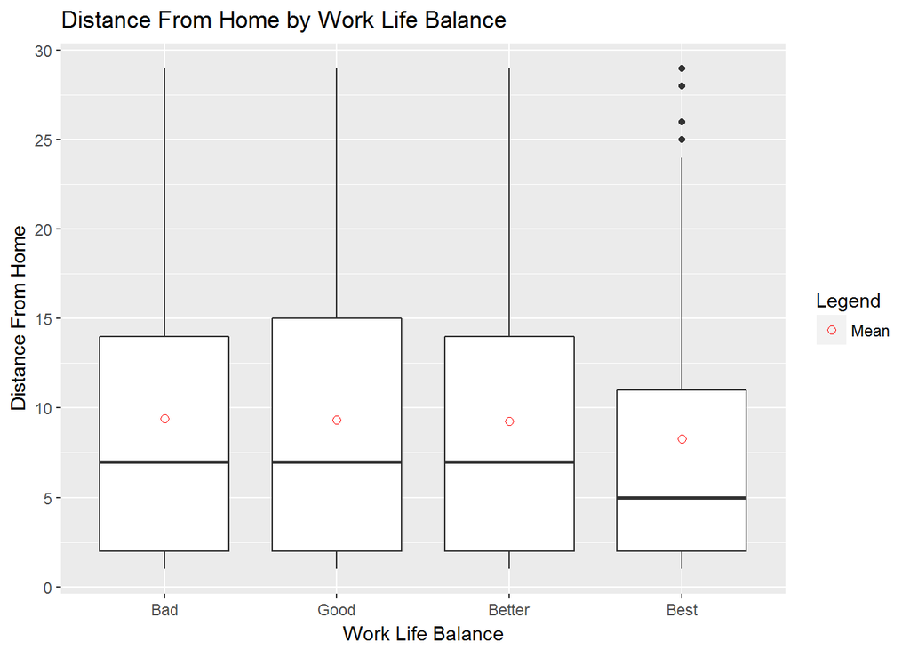

Employees with *Low* job involvement tend to be younger than other groups. Could be this related to the usual obstacles when new employees join a company as it takes time to be accustomed within the company’s culture?

Additionally, employees who rated their work life balance as *Best* had shorted distance to their homes. This could be a factor of why employees like their jobs and less likely to resign.

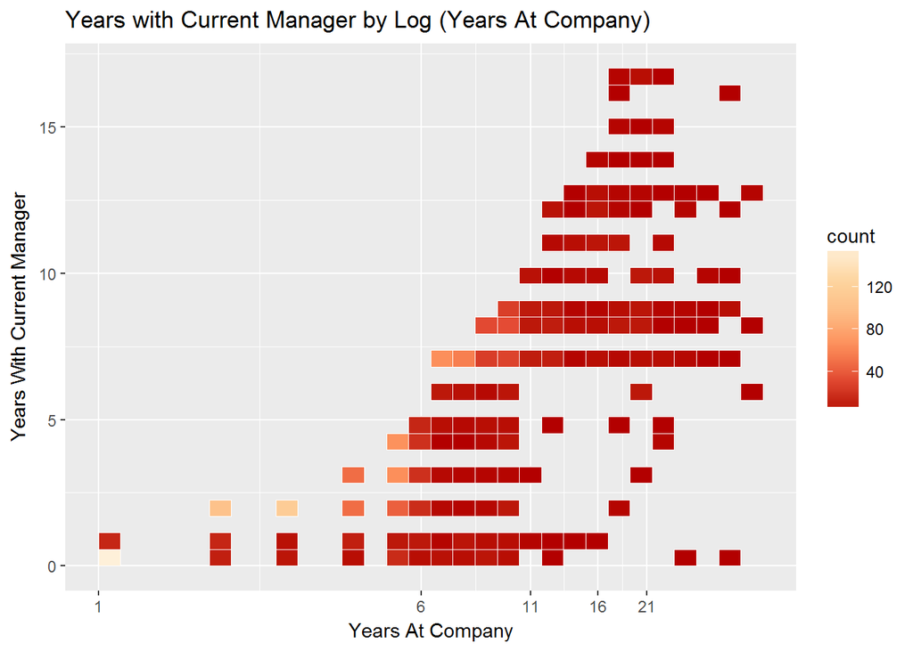

There seems to be a consistent pattern of a segment of employees reporting to the same manager through their entire company’s career. However, there is a different story after 10 years spent at the company where a notable percentage of employees either left the company or changed their role and hence reporting to a new manager.

Statistical summary for employees’ years with their current manager over their entire company’s tenure:

```
##    Min. 1st Qu.  Median    Mean 3rd Qu.    Max.
##  0.0625  0.5000  0.6875  0.6803  0.8750  1.0000
```

```
##
##  Pearson's product-moment correlation
##
## data:  hr$YearsAtCompany and hr$YearsWithCurrManager
## t = 46.123, df = 1468, p-value < 2.2e-16
## alternative hypothesis: true correlation is not equal to 0
## 95 percent confidence interval:
##  0.7474818 0.7892985
## sample estimates:
##       cor
## 0.7692124
```

The Pearson’s coefficient correlation is roughly 0.8 which represent a positive relationship, however we should keep in mind that the variable *YearsAtCompany* is a super set of the other one.

Are there specific educations fields in which they are associated with attrited employees?

```
## # A tibble: 6 x 3
## # Groups:   EducationField [6]
##     EducationField Attrition Total
##             <fctr>    <fctr> <int>
## 1    Life Sciences       Yes    89
## 2          Medical       Yes    63
## 3        Marketing       Yes    35
## 4 Technical Degree       Yes    32
## 5            Other       Yes    11
## 6  Human Resources       Yes     7
```

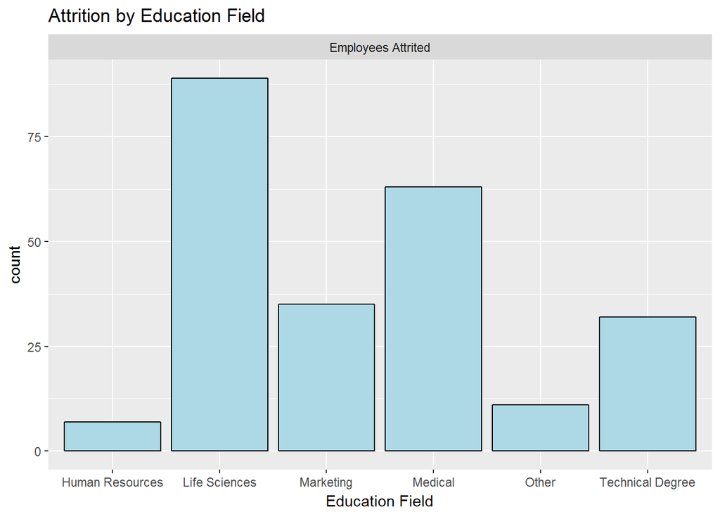

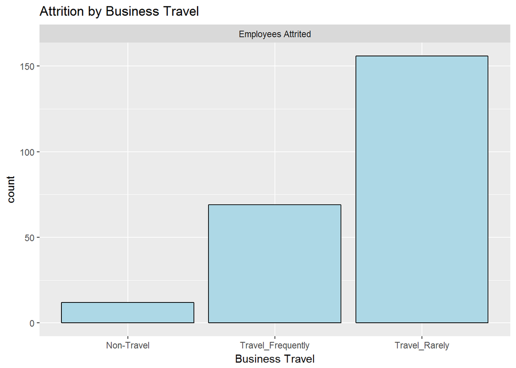

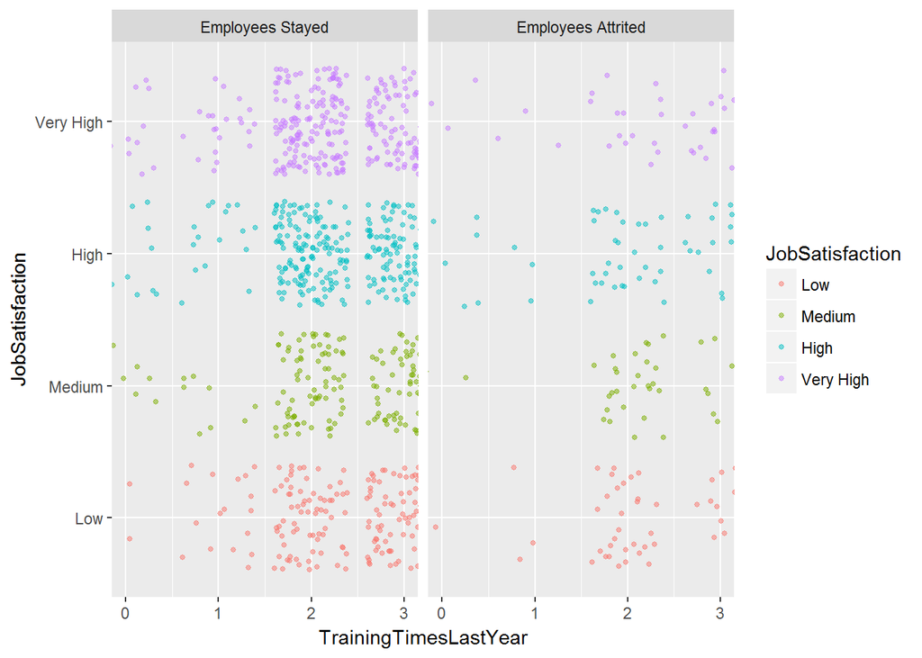

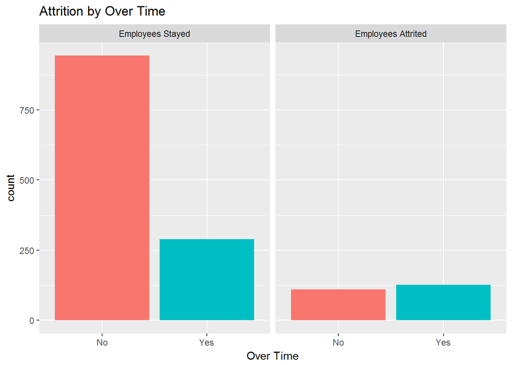

# Bivariate Analysis

### Talk about some of the relationships you observed in this part of the investigation. How did the feature(s) of interest vary with other features in the dataset?

Since the dataset has more than 30 variables, many of them do have correlations with each other and might often be unusual For example, business travel variable has showed unexpected correlation with attrition in regards with employees who travel rarely. Moreover, the employees who were doing overtime had higher probability to leave the company than those who were not.

### Did you observe any interesting relationships between the other features (not the main feature(s) of interest)?

The variable education field has shown an interesting behavior in an unexpected way towards the attrition level, where Life Sciences accounted for the greatest level of attrited employees’ education field. Likewise, employees apparently have shown interest in having shorter distance to their homes and that reflected as *Best* on their response of work life balance query.

### What was the strongest relationship you found?

The relationship between Overtime and employees’ attrition had surely shown a strong relationship, and that might be a result of not being rewarded (or promoted) for their hard efforts.

# Multivariate Plots Section

Now that we explored two vairables at a time, we will explore more variables besides their reponse to the attrition level.

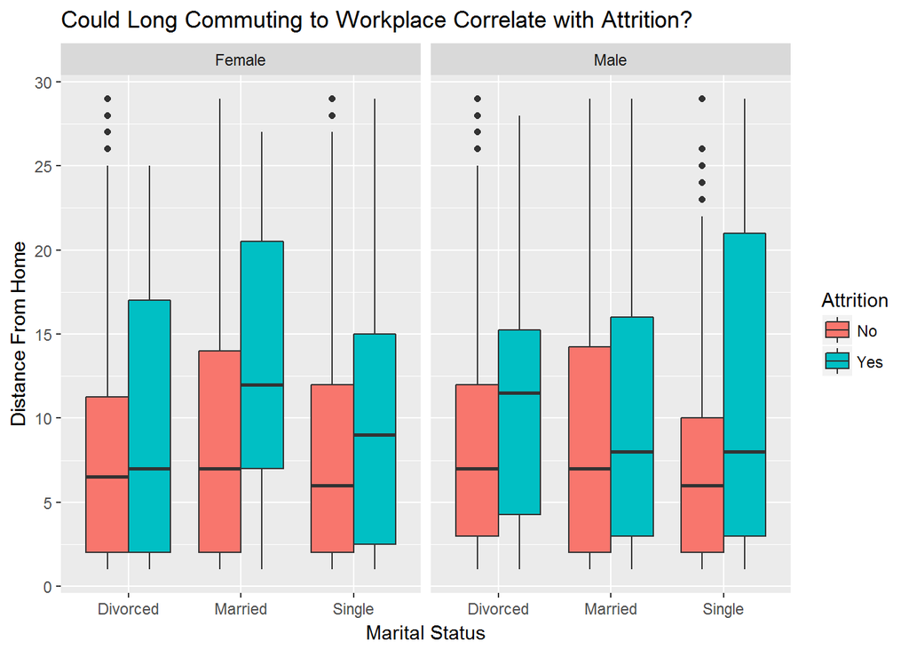

This collection of boxplots shed the lights on how distance from home could positively correlate with higher attrition level. We can see the median of attrited employees had to commute longer than those who stayed on each instance for both gender alongside their marital status.

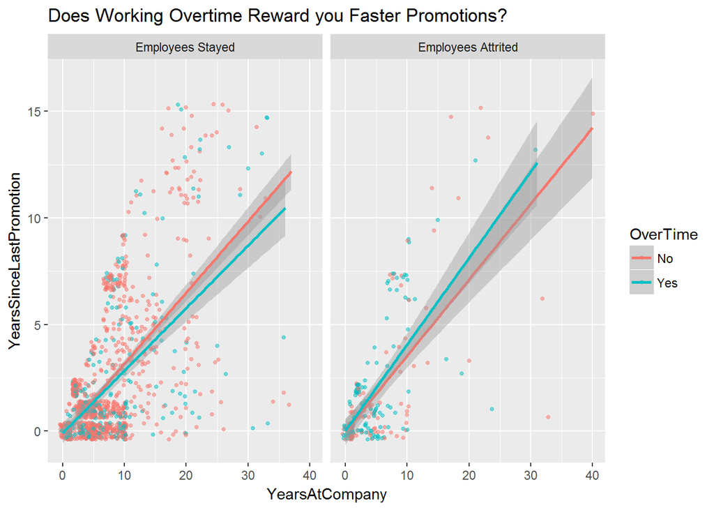

# Multivariate Analysis

### Talk about some of the relationships you observed in this part of the investigation. Were there features that strengthened each other in terms of looking at your feature(s) of interest?

A strong correlation was observed when plotting the attrition, distance from home, and marital status where we can see the longer the distance from home, the more likely the chance of an employee’s attrition rises, and the same pattern replicates over the each marital status (Married, Divorced and Single).

### Were there any interesting or surprising interactions between features?

Overtime’s impact on employees’ attritons.

# Final Plots and Summary

### Plot One

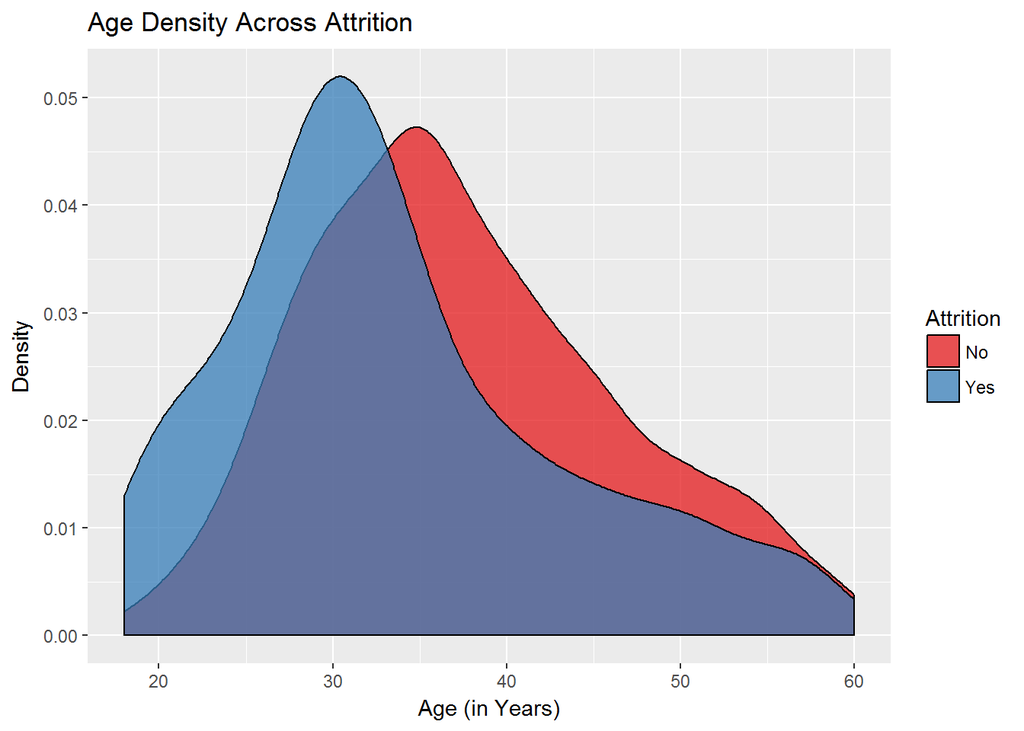

### Plot Two

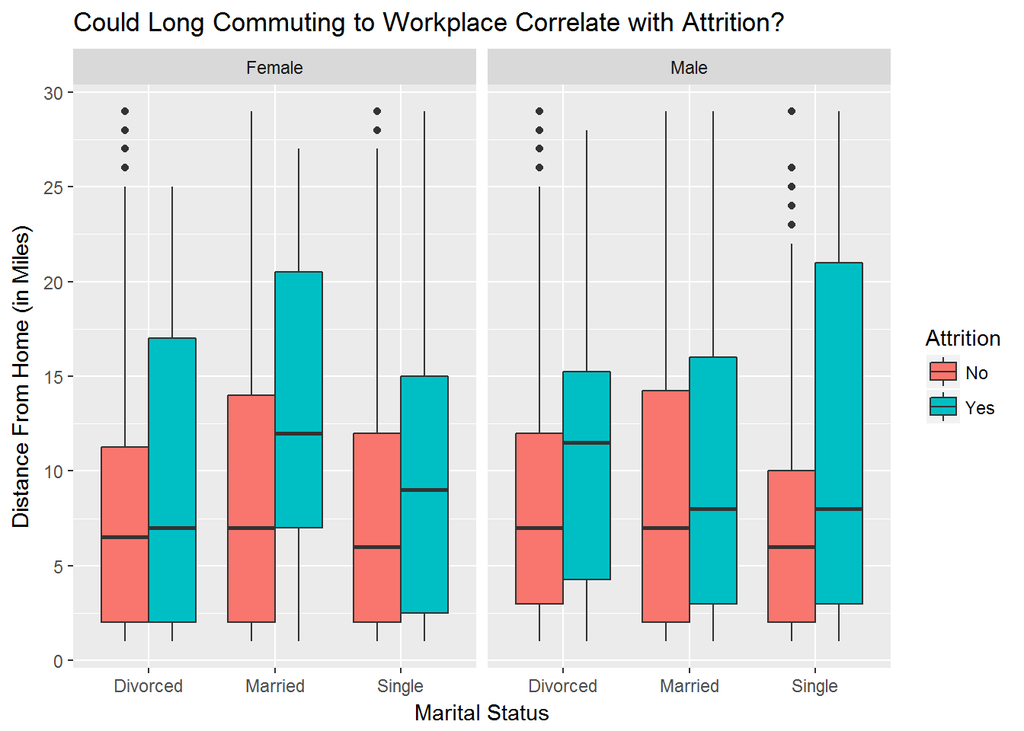

### Plot Three

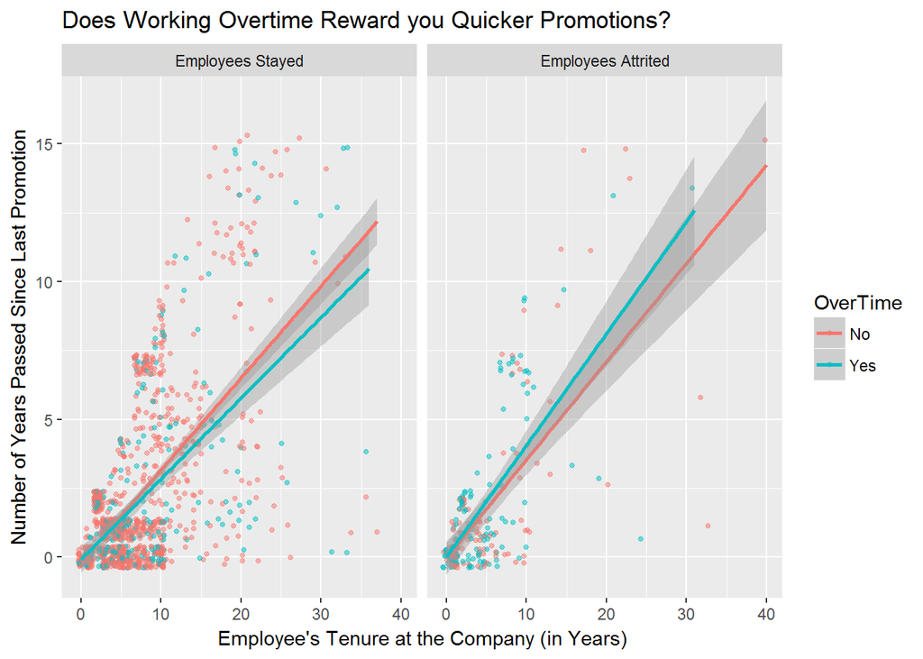

# Reflection

One struggle that I encountered at the beginning is the sheer number of variables combined with my limited domain knowledge of HR’s analytics field, but through making a couple explorations and visualizations I started to build intuitive sense which helped me diving with confidence into exploring and wrangling complex relationships of variables, and hence extracting valuable insights.

At the end, we have seen strong features that could determine employees’ attrition such as (Over Time, Distance From Home, Years Since Last Promotion) that can be incorporated in a predictive model as a next level of data science’s cycle.